# Introduction to Python Programming by Edward Fine

## Python Graphics & Visualization

Matplotlib is a powerful plotting library for Python that allows engineers to easily create visual representations of data. It is a widely used library in the scientific Python ecosystem and is suitable for creating a wide variety of plots, including line plots, scatter plots, bar plots, histograms, and many other types of plots

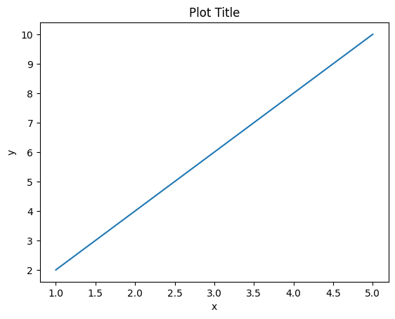

```python
import matplotlib.pyplot as plt

x = [1,2,3,4,5]
y = [2,4,6,8,10]
plt.plot(x,y)
plt.xlabel("x")
plt.ylabel("y")
plt.title("Plot Title")

plt.show()
```

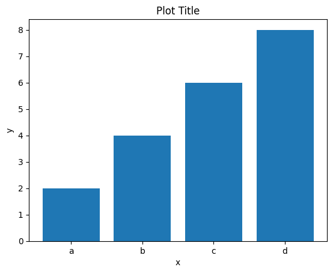

```python
# Create some data

x = ['a','b','c','d']
y = [2,4,6,8]

plt.bar(x,y)
plt.xlabel("x")
plt.ylabel("y")
plt.title("Plot Title")

plt.show()
```

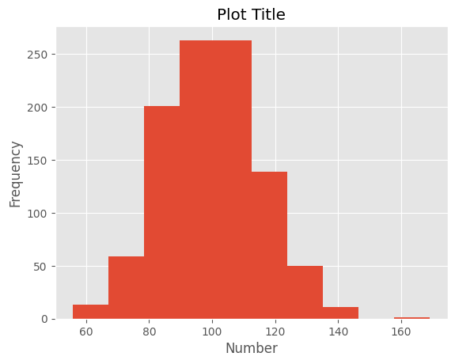

```python
import matplotlib.style as style
data = np.random.normal(100,15,1000)
plt.hist(data)
style.use("ggplot")

plt.xlabel("Number")
plt.ylabel("Frequency")
plt.title("Plot Title")

plt.show()
```

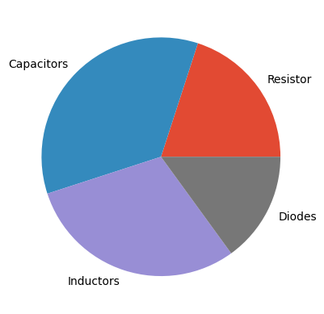

```python
labels = ["Resistor", "Capacitors", "Inductors", "Diodes"]
sizes=[20,35,30,15]

plt.pie(sizes,labels=labels)
style.use("ggplot")
plt.show()
```

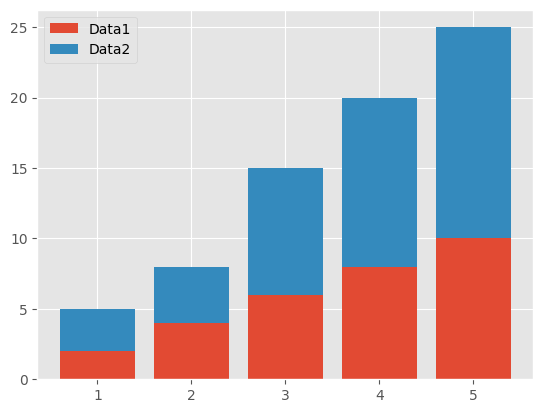

```python
x = [1,2,3,4,5]
y1 = [2,4,6,8,10]
y2 = [3,4,9,12,15]

plt.bar(x,y1, label="Data1")
plt.bar(x,y2,bottom = y1, label="Data2")
plt.legend()
style.use('fast')
plt.show()
```

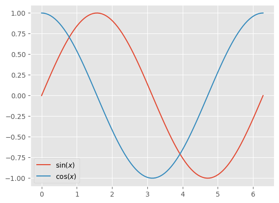

```python
import numpy as np
import matplotlib.pyplot as plt

x = np.linspace(0,2*np.pi,100)

y1 = np.sin(x)
y2 = np.cos(x)

plt.plot(x,y1,label="$\sin(x)$")
plt.plot(x,y2,label="$\cos(x)$")
plt.legend()
plt.show()
```

Plot $f(x,y) = (x^3+3y^2)e^(1-x^2-y^2)$

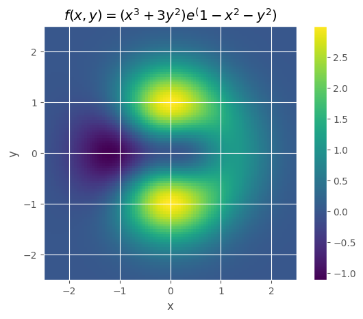

```python
x = np.linspace(-2.5,2.5,100)
y = np.linspace(-2.5,2.5,100)
x,y = np.meshgrid(x,y)

f = (x**3+3*y**2)*np.exp(1-x**2-y**2)
plt.imshow(f,extent=[-2.5,2.5,-2.5,2.5], origin='lower')
plt.colorbar()
plt.xlabel('x')
plt.ylabel('y')
plt.title('$f(x,y) = (x^3+3y^2)e^(1-x^2-y^2)$')
plt.show()
```

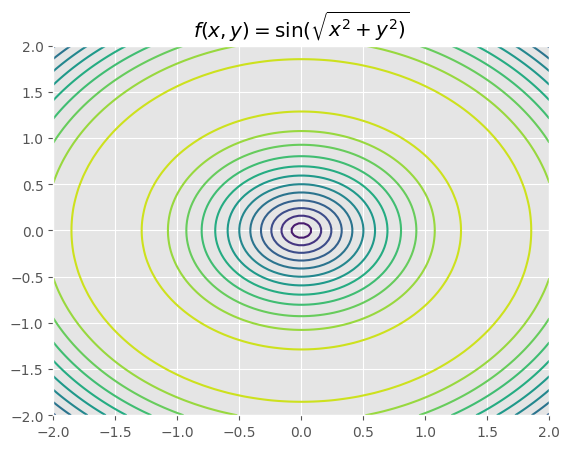

```python
x = np.linspace(-2,2,100)
y = np.linspace(-2,2,100)
x,y = np.meshgrid(x,y)


f = np.sin(np.sqrt(x**2+y**2))

plt.contour(x,y,f,levels=15)
plt.title("$f(x,y) = \sin(\sqrt{x^2 + y^2)}$")
plt.show()
```

[figure not shown]

```python
x = np.linspace(-2,2,100)
y = np.linspace(-2,2,100)
x,y = np.meshgrid(x,y)


f = np.sin(np.sqrt(x**2+y**2))
fig = plt.figure()
# ax = fig.add_subplot(111,projections='3d')
# ax.plot_wirefreame(x,y,f)
plt.title("$f(x,y) = \sin(\sqrt{x^2 + y^2)}$")
plt.show()
```

Create plots of $y(x) = x$, $y(x) = x^2$, $y(x) = x^3 $, $y(x) = \sqrt{x}$, $y(x) = e^x$, and $y(x) = log(x)$

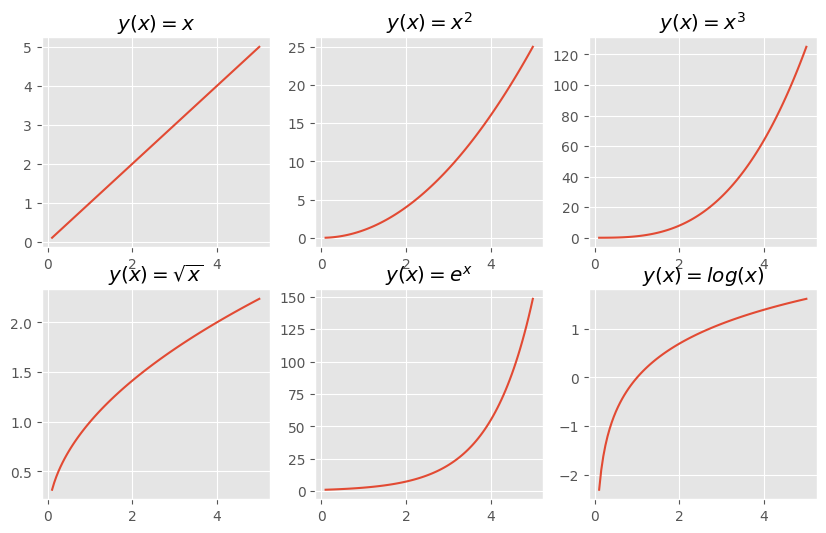

```python
# Define the x-values
x = np.linspace(0.1,5,100)

# Define the functions
y1 = x
y2 = x**2
y3 = x**3
y4 = np.sqrt(x)
y5 = np.exp(x)
y6 = np.log(x)

fig, axs = plt.subplots(2,3,figsize=(10,6))
axs[0,0].plot(x,y1)
axs[0,0].set_title('$y(x) = x$')
axs[0,1].plot(x,y2)
axs[0,1].set_title('$y(x) = x^2$')
axs[0,2].plot(x,y3)
axs[0,2].set_title('$y(x) = x^3$')
axs[1,0].plot(x,y4)
axs[1,0].set_title('$y(x) = \sqrt{x}$')
axs[1,1].plot(x,y5)
axs[1,1].set_title('$y(x) = e^x$')
axs[1,2].plot(x,y6)
axs[1,2].set_title('$y(x) = log(x)$')
plt.show()
```

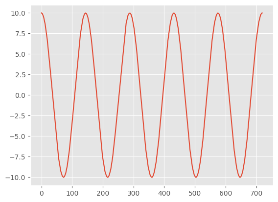

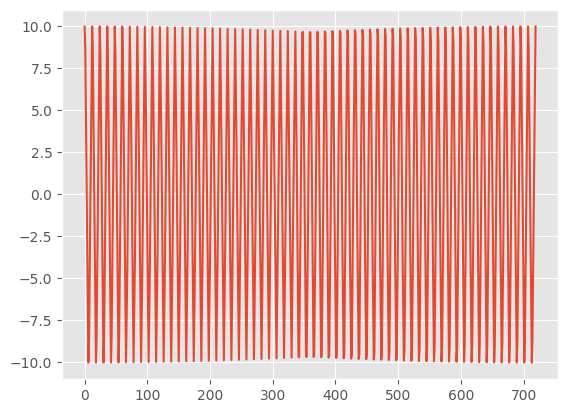

```
<function matplotlib.pyplot.show(close=None, block=None)>
```

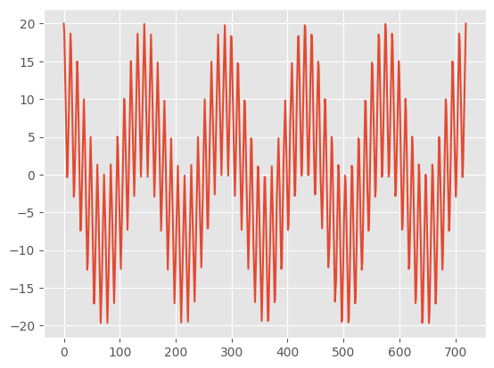

```python
# Define the signal parameters

f1,f2 = 5,60
A1,A2 = 10,0.5
fs = 12*f2
T=1
t= np.linspace(0,T,T*fs)

x1=A1*np.cos(2*np.pi*f1*t)
x2 =A1*np.cos(2*np.pi*f2*t)
x=x1+x2

plt.plot(x1)
plt.show()
plt.plot(x2)
plt.show()
plt.plot(x)
plt.show
```

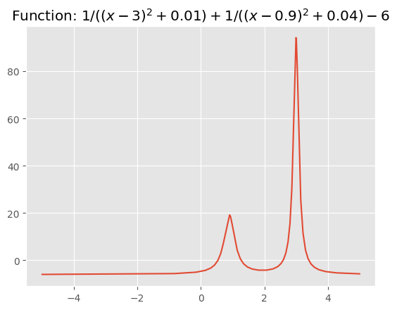

```python
def f(x):
    return 1/((x-3)**2 +0.01) + 1/((x-0.9)**2+0.04)-6

x = np.linspace(-5,5,1000)

y = f(x)

plt.plot(x,y)
plt.title("Function: $1/((x-3)^2+0.01) + 1/((x-0.9)^2+0.04)-6$")
plt.show()
```

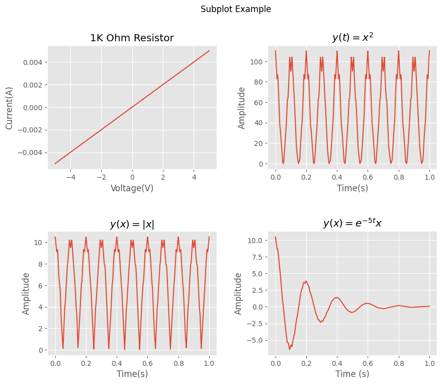

```python
R = 1000
V = np.linspace(-5,5,1000)
I = V/R

# Define the signals
f1 = 5
f2 = 60
A1 = 10
A2 = 0.5
t = np.linspace(0,1,1000)
x = A1*np.cos(2*np.pi*f1*t)+A2*np.cos(2*np.pi*f2*t)

y1 = x**2
y2 = np.abs(x)
y3 = np.exp(-5*t)*x

fig,axs = plt.subplots(2,2, figsize=(10,8))
fig.subplots_adjust(hspace=0.5,wspace=0.3)
fig.suptitle("Subplot Example")

axs[0,0].plot(V,I)
axs[0,0].set_title("1K Ohm Resistor")
axs[0,0].set_xlabel("Voltage(V)")
axs[0,0].set_ylabel("Current(A)")

axs[0,1].plot(t,y1)
axs[0,1].set_title("$y(t) = x^2$")
axs[0,1].set_xlabel("Time(s)")
axs[0,1].set_ylabel("Amplitude")

axs[1,0].plot(t,y2)
axs[1,0].set_title("$y(x) = |x|$")
axs[1,0].set_xlabel("Time(s)")
axs[1,0].set_ylabel("Amplitude")

axs[1,1].plot(t,y3)
axs[1,1].set_title("$y(x) = e^{-5t}x$")
axs[1,1].set_xlabel("Time (s)")
axs[1,1].set_ylabel("Amplitude")

plt.show()
```

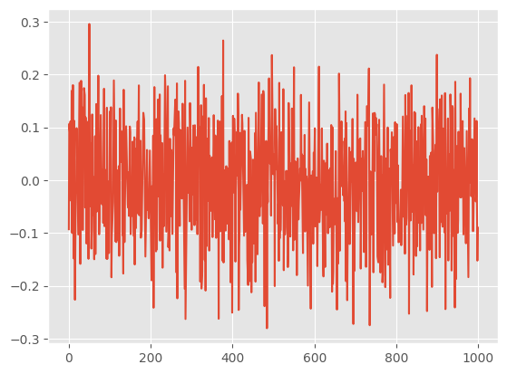

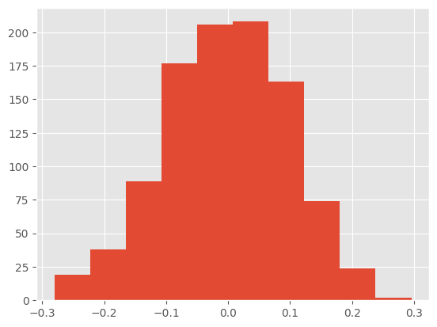

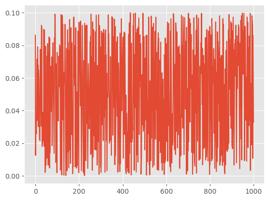

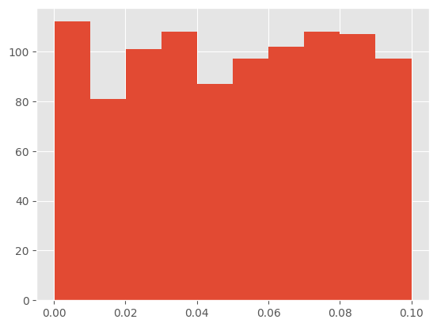

```python
mu,sigma = 0,0.1
norm_data = np.random.normal(mu,sigma,1000)
uniform_data = np.random.uniform(mu,sigma,1000)

plt.plot(norm_data)
plt.show()

plt.hist(norm_data)
style.use("ggplot")
plt.show()

plt.plot(uniform_data)
plt.show()

plt.hist(uniform_data)
style.use("ggplot")
plt.show()
```

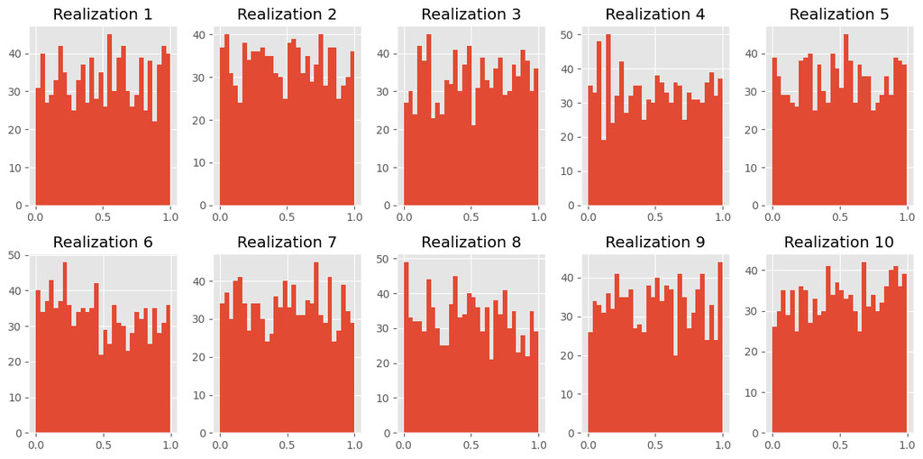

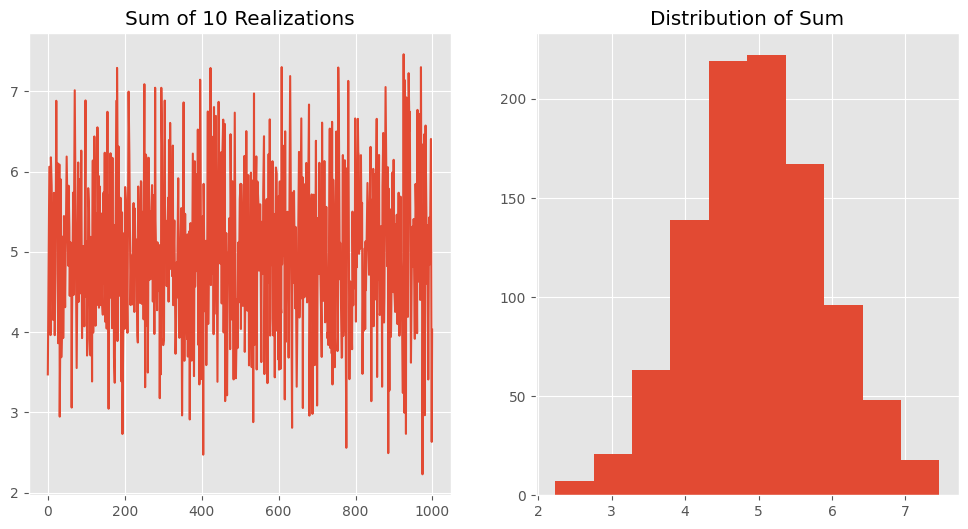

```python
n = 1000

uniform_data = np.random.uniform(0,1,(10,n))
uniform_data.shape
fig,axs = plt.subplots(2,5,figsize=(12,6))
axs = axs.flatten()

for i in range(10):
    axs[i].hist(uniform_data[i], bins=30)
    axs[i].set_title(f"Realization {i+1}")

plt.tight_layout()
plt.show()

sum_uniform_data = np.sum(uniform_data,axis=0)

fig,axs = plt.subplots(1,2,figsize=(12,6))
axs = axs.flatten()
axs[0].plot(sum_uniform_data)
axs[0].set_title("Sum of 10 Realizations")
axs[1].hist(sum_uniform_data)
axs[1].set_title("Distribution of Sum")
plt.show()
```

```python
import matplotlib.pyplot as plot
import numpy as np

def projectile_motion(v0, theta0):
    # ProjectileMotion calculates the horizontal range, maximum height,
    # location of the maximum height, and displays a plot of the trajectory
    # for a projectile with the initial velocity v0 and initial angle theta0.
    #
    # Inputs:
    # v0 = initial velocity
    # theta0 = initial angle
    #
    # Outputs:
    # range = horizontal distance
    # max_height = the maximum y value
    # max_height_x = where on the x axis the max height occurs
    # h_pos = matrix of the x,y positions of the projectile over time.

    g=9.8
    theta0 = theta0 * (np.pi/180)
    vx = v0*np.cos(theta0)
    vy = v0*np.sin(theta0)

    # Time of flights
    t_flight = 2*vy/g

    # Calculate Range
    range = vx * t_flight

    # Calculate maximum height
    max_height = vy**2/(2*g)

    # Calculate location of max
    max_height_x = vx*vy/g

    # Calculate the x and y positions over time
    t = np.linspace(0,t_flight,1000)
    x_pos = vx*t
    y_pos = vy*t+(.5*-g*(t**2))

    # Store x and y postions in h_pos matrix
    h_pos = [x_pos,y_pos]

    # Plot the trajectory
    plot.figure(edgecolor='white')
    plot.plot(x_pos,y_pos)
    plot.xlim([0,25])
    plot.ylim([0,25])
    plot.xlabel("Horizonal Position (m)")
    plot.ylabel("Vertical Position (m)")
    plot.title("Projectile Trajectory")

    return range, max_height,max_height_x,h_pos
```

```
Results for the Velocity of 15 and theta of 70 degrees:
Range: 14.76
Max Height: 10.14
Max Height Location: 7.38
```

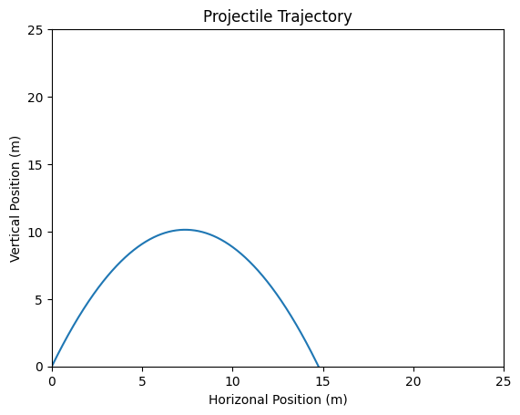

```python
v0 = 15
theta0=70
range,max_height,max_height_x,h_pos = projectile_motion(v0,theta0)
print(f"Results for the Velocity of {v0} and theta of {theta0} degrees: \nRange: {range:.2f} \nMax Height: {max_height:.2f} \nMax Height Location: {max_height_x:.2f}")
```

```
Results for the Velocity of 20 and theta of 30 degrees:
Range: 35.35
Max Height: 5.10
Max Height Location: 17.67
```

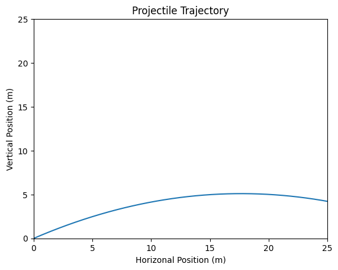

```python
v0 = 20
theta0=30
range,max_height,max_height_x,h_pos = projectile_motion(v0,theta0)
print(f"Results for the Velocity of {v0} and theta of {theta0} degrees: \nRange: {range:.2f} \nMax Height: {max_height:.2f} \nMax Height Location: {max_height_x:.2f}")
```